# act_report

## Report: act_report

This report describe three insights regarding analyzing WeRateDogs project

1. Which breed of dog recieved the highest likes and retweets?
2. Tweet distribution based on the number of favorites and retweets
3. What is the most used slang (doggo, puppo, pupper, flooper)?

Each insight has its own visualization

#### 1. Which breed of dog recieved the highest likes and retweets?

```python
import pandas as pd
import matplotlib.pyplot as plt
%matplotlib inline
```

```python
master_df = pd.read_csv('twitter_archive_master.csv')
```

The average retweet and favorite count for each breed was gotten programmatically A barchart is used to show the relationship

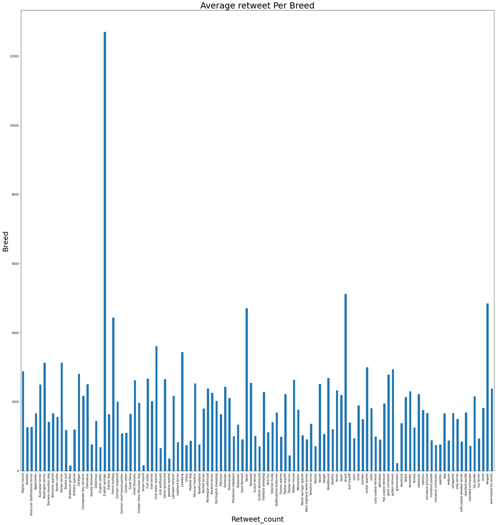

```python
master_df.groupby(['breed'])['retweet_count'].mean().plot(kind="bar", figsize=(30,30));
plt.title('Average retweet Per Breed', fontsize=30)
plt.xlabel('Retweet_count', fontsize=25)
plt.ylabel('Breed', fontsize=25)
plt.show()
```

- The graph shows the average retweet count with regards to Breed
- From the graph it shows English springler has the highest likes

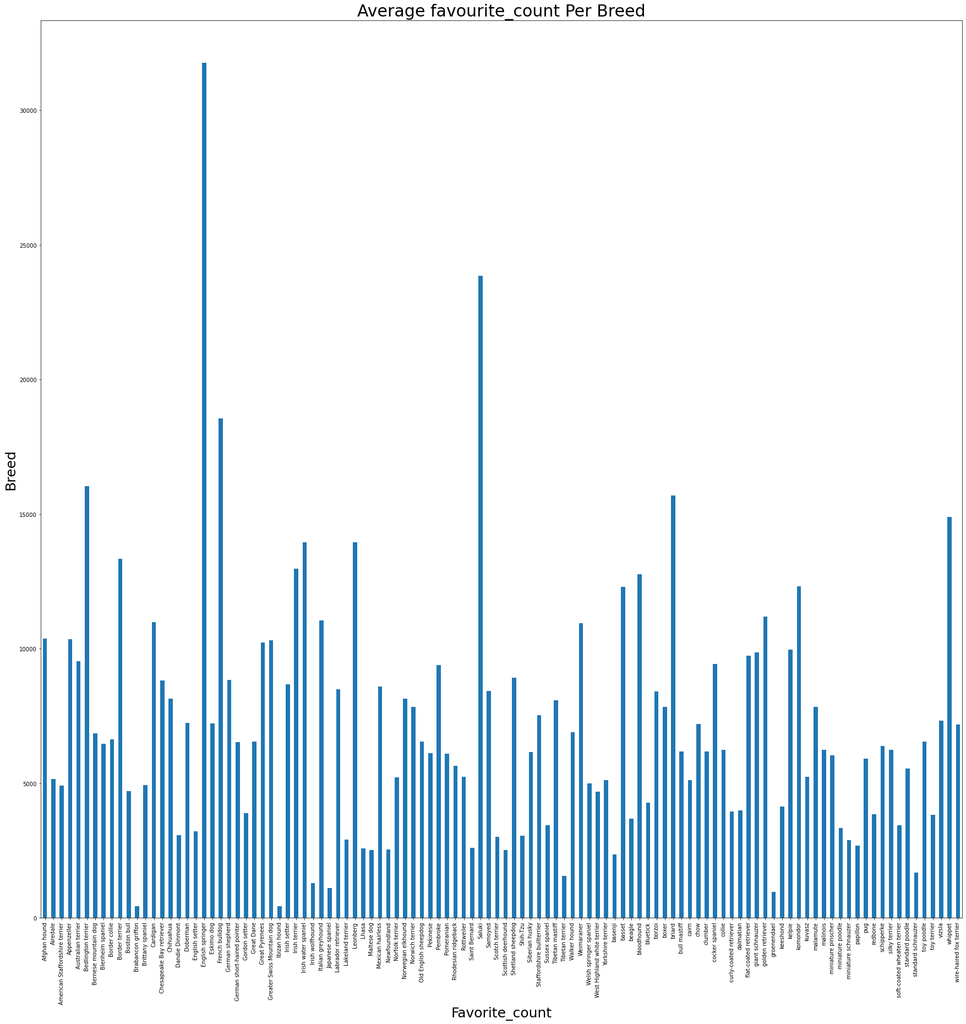

```python
master_df.groupby(['breed'])['favorite_count'].mean().plot(kind="bar", figsize=(30,30));
plt.title('Average favourite_count Per Breed', fontsize=30)
plt.xlabel('Favorite_count', fontsize=25)
plt.ylabel('Breed', fontsize=25)
plt.show()
```

The graph shows the average favourite count with regards to Breed From the graph it shows English springler has the highest likes

#### 2. Twitter distribution based on the number of favorites and retweets

To show the relationship between favourite and retweet a scatter plot was used

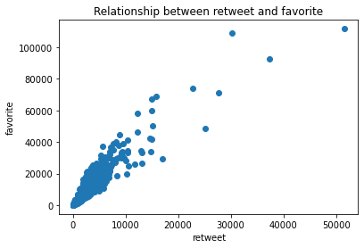

```python
# x-axis
plt.xlabel('retweet')
# y-axis
plt.ylabel('favorite')
# Title of the histogram
plt.title('Relationship between retweet and favorite')
plt.scatter(master_df['retweet_count'], master_df['favorite_count'])
plt.show()
```

- There is a positive correlation between retweet and favorite
- The higher the retweet the higher the favorite

#### 3. What is the most used slang (doggo, puppo, pupper, flooper)?

The count of slang is shown below:

```python
slage_count = pd.Series(master_df['slang']).value_counts(ascending = False)
slage_count
```

```
none       1200
pupper      121
doggo        42
puppo        16
floofer       5
Name: slang, dtype: int64
```

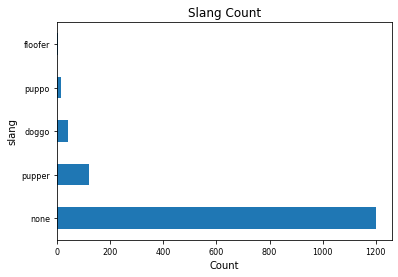

```python
diagram = slage_count.plot.barh(fontsize = 8)
diagram.set(title = 'Slang Count')
diagram.set_xlabel('Count')
diagram.set_ylabel('slang')
plt.show()
```

Most dogs do not have either of the 4 slangs, for the dogs with slangs pupper has the highest count

```python
df_breed = master_df.groupby(['slang'],as_index=False)['favorite_count'].mean()
df_breed.sort_values('favorite_count', axis=0, ascending=False, inplace=False, kind='quicksort', na_position='last')
```

|  | slang | favorite_count |
| --- | --- | --- |
| 0 | doggo | 12018.184211 |
| 4 | puppo | 10303.428571 |
| 1 | floofer | 8185.800000 |
| 2 | none | 7541.429315 |
| 3 | pupper | 6304.974790 |

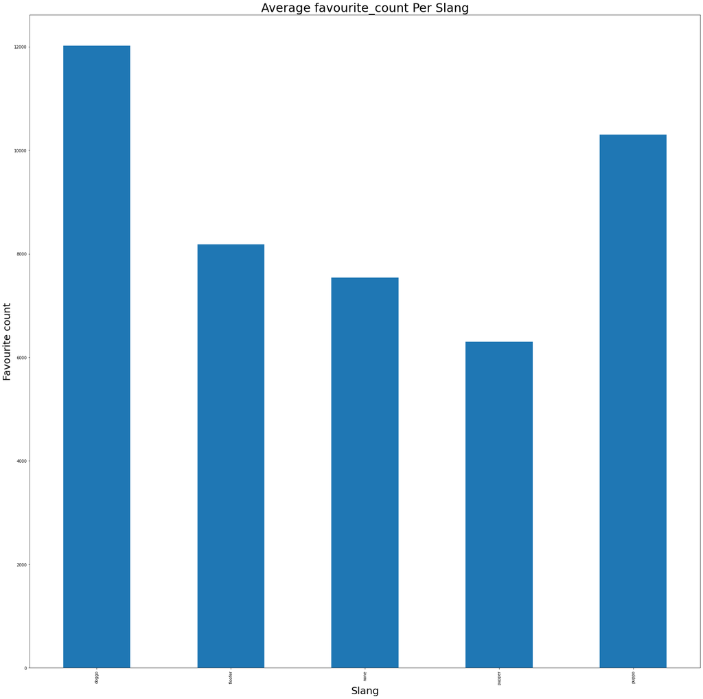

```python
master_df.groupby(['slang'])['favorite_count'].mean().plot(kind="bar", figsize=(30,30));
plt.title('Average favourite_count Per Slang', fontsize=30)
plt.xlabel('Slang', fontsize=25)
plt.ylabel('Favourite count', fontsize=25)
plt.show()
```

```python
df_breed = master_df.groupby(['slang'],as_index=False)['retweet_count'].mean()
df_breed.sort_values('retweet_count', axis=0, ascending=False, inplace=False, kind='quicksort', na_position='last')
```

|  | slang | retweet_count |
| --- | --- | --- |
| 0 | doggo | 2993.289474 |
| 4 | puppo | 2530.500000 |
| 2 | none | 2041.601041 |
| 1 | floofer | 1816.200000 |
| 3 | pupper | 1787.268908 |

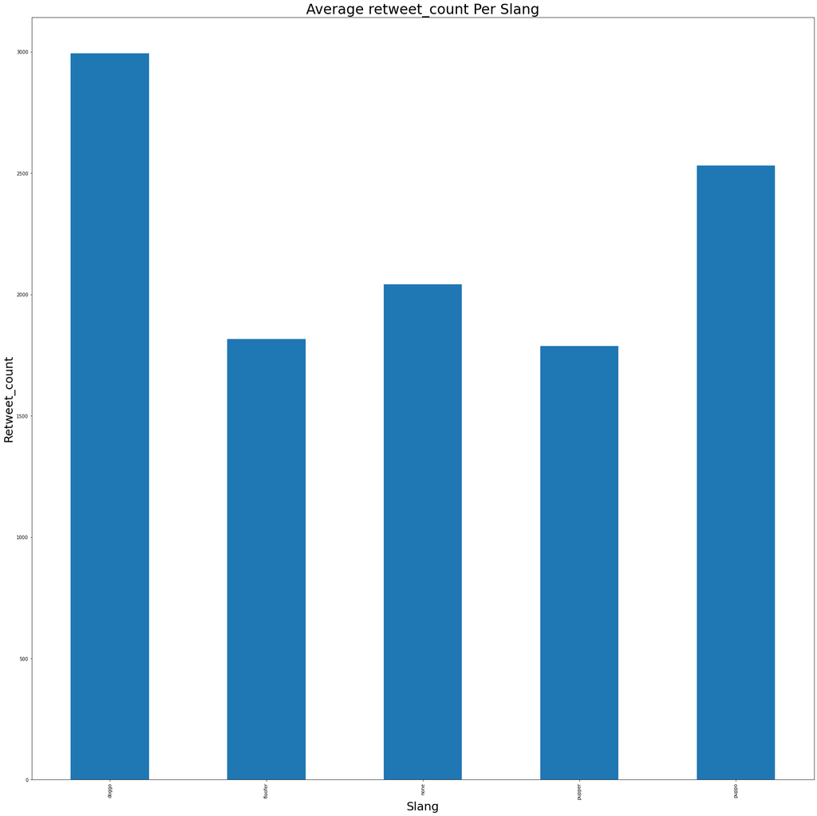

```python
master_df.groupby(['slang'])['retweet_count'].mean().plot(kind="bar", figsize=(30,30));
plt.title('Average retweet_count Per Slang', fontsize=30)
plt.xlabel('Slang', fontsize=25)
plt.ylabel('Retweet_count', fontsize=25)
plt.show()
```

Dogs called doggo have the highest favourite and retweet count

- There is a positive correlation between retweet and favorite
- The higher the retweet the higher the favorite